# Exploring red wine data

Babatunji Ogunjobi

# Introduction

This project leverages R and exploratory data analysis to analyze a dataset that aims to compare the quality of wine looking at different constituent elements contained within it

The data analyzed can be sourced from [Here](https://www.google.com/url?q=https://s3.amazonaws.com/udacity-hosted-downloads/ud651/wineQualityReds.csv&sa=D&ust=1537996947818000)

> Within the dataset, i will be exploring various elements and how they affect the overall quality of the wine

# Univariate Plots Section

```
## Observations: 1,599
## Variables: 12
## $ fixed.acidity        <dbl> 7.4, 7.8, 7.8, 11.2, 7.4, 7.4, 7.9, 7.3, ...
## $ volatile.acidity     <dbl> 0.700, 0.880, 0.760, 0.280, 0.700, 0.660,...
## $ citric.acid          <dbl> 0.00, 0.00, 0.04, 0.56, 0.00, 0.00, 0.06,...
## $ residual.sugar       <dbl> 1.9, 2.6, 2.3, 1.9, 1.9, 1.8, 1.6, 1.2, 2...
## $ chlorides            <dbl> 0.076, 0.098, 0.092, 0.075, 0.076, 0.075,...
## $ free.sulfur.dioxide  <dbl> 11, 25, 15, 17, 11, 13, 15, 15, 9, 17, 15...
## $ total.sulfur.dioxide <dbl> 34, 67, 54, 60, 34, 40, 59, 21, 18, 102, ...
## $ density              <dbl> 0.9978, 0.9968, 0.9970, 0.9980, 0.9978, 0...
## $ pH                   <dbl> 3.51, 3.20, 3.26, 3.16, 3.51, 3.51, 3.30,...
## $ sulphates            <dbl> 0.56, 0.68, 0.65, 0.58, 0.56, 0.56, 0.46,...
## $ alcohol              <dbl> 9.4, 9.8, 9.8, 9.8, 9.4, 9.4, 9.4, 10.0, ...
## $ quality              <ord> 5, 5, 5, 6, 5, 5, 5, 7, 7, 5, 5, 5, 5, 5,...
```

The dataset comprises 12 variables, with 1599 observations.The Quality variable is discrete and the others are continuous

## Quality

```
##   3   4   5   6   7   8
##  10  53 681 638 199  18
```

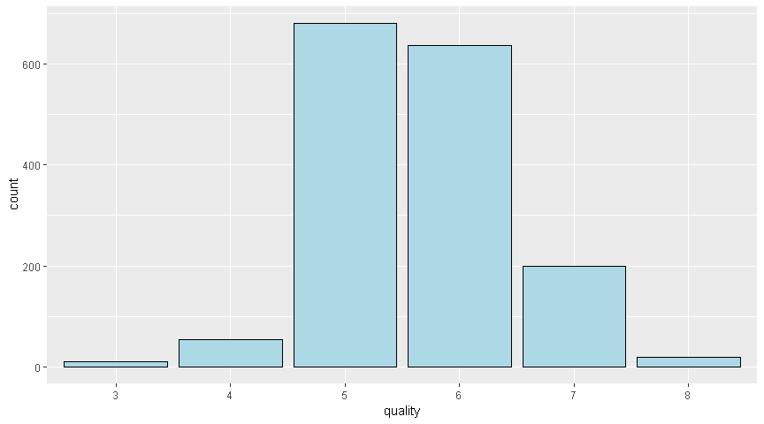

[output not shown]

From the histogram, it can be infered that having combined the constituent elements that form red wine in different rations, most end with a quality of between 5 & 6(median quality).The histogram also shows that no wines exist with a quality worse than 3 and no wines within the dataset have quality higher than 8.

## Fixed Acidity

```
##    Min. 1st Qu.  Median    Mean 3rd Qu.    Max.
##    4.60    7.10    7.90    8.32    9.20   15.90
```

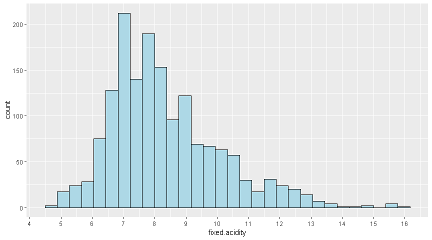

The fixed acidity of the wines fall on a median of 7.90 $g/dm^3$. A larger proportion of the wines have a median fixed acidity falling between 7.10 and 9.20 as such the distribution of fixed acidity is slightly tends to the right of the chart. A few outliers exist a beyond the 14 fixed acidity range

## Volatile acidity

```
##    Min. 1st Qu.  Median    Mean 3rd Qu.    Max.
##  0.1200  0.3900  0.5200  0.5278  0.6400  1.5800
```

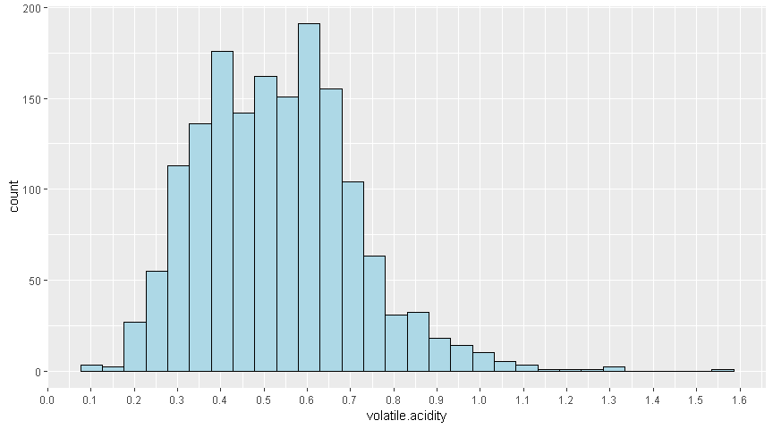

A few outliers exist towards the end of the scale. The volatile acidity is non-symmetric and bimodal with two peaks at 0.39 and 0.64. The median value is 0.52. Most observations fall within the areas of the peak which ranges between 0.39 to 0.64.

## Citric acid

```
##    Min. 1st Qu.  Median    Mean 3rd Qu.    Max.
##   0.000   0.090   0.260   0.271   0.420   1.000
```

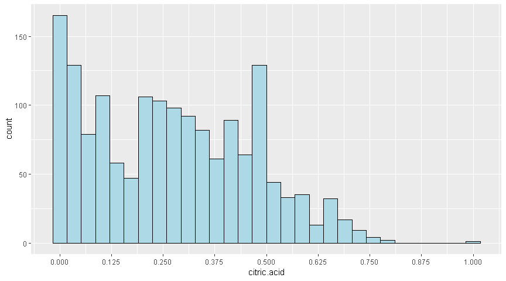

Most wines have less than 1 $g/dm^3$ of citric acid.The data & consequently the chart shows that only a small quantity of citric acid is used. The distribution tends to the right with some highs & lows.A single outlier exists on the right side containing 1 $g/dm^3$ of citric acid.This is absolutely normal as only a little amount of citric acid is neccessary to improve freshness and flavour for wines.

## Residual sugar

```
##    Min. 1st Qu.  Median    Mean 3rd Qu.    Max.
##   0.900   1.900   2.200   2.539   2.600  15.500
```

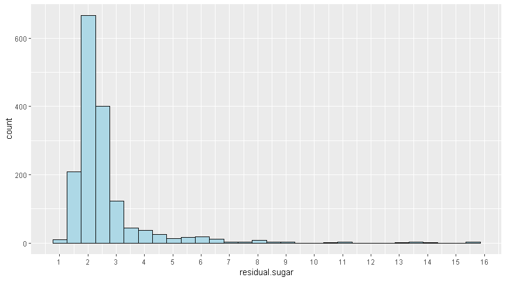

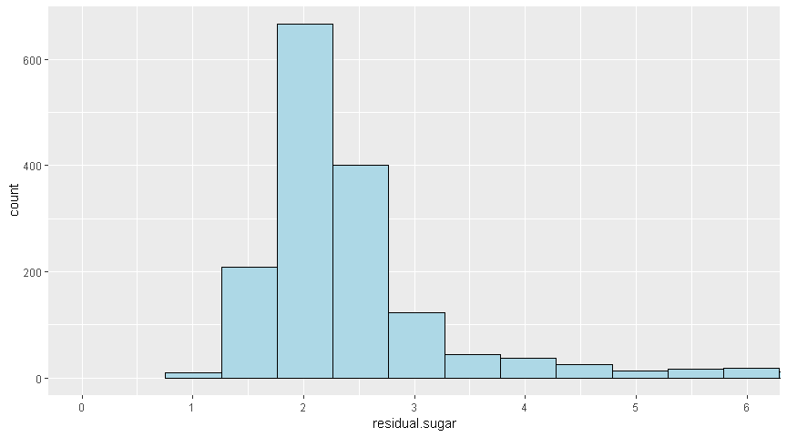

The distribution of residual sugar has a median value of 2.2 $g/dm^3$ and there is a major trend toward the right of the chart depicting an increase in residual sugar beyond the median point. Also,there are many outliers on the right side of the main peak.I believe this is because for improved alcohol levels, more sugar will be needed during fermentation & thus leading to higher chances of having residual sugar.

## Chlorides

```
##    Min. 1st Qu.  Median    Mean 3rd Qu.    Max.
## 0.01200 0.07000 0.07900 0.08747 0.09000 0.61100
```

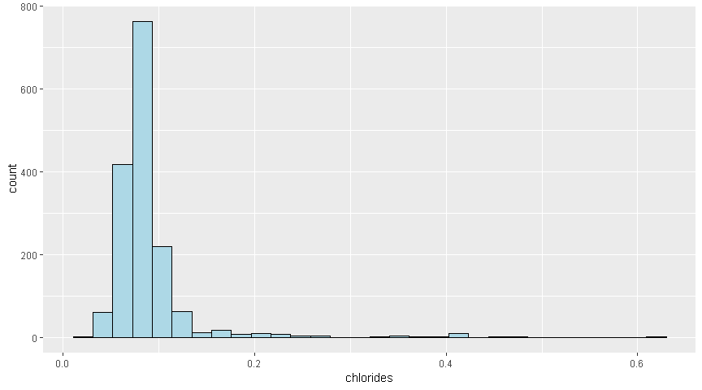

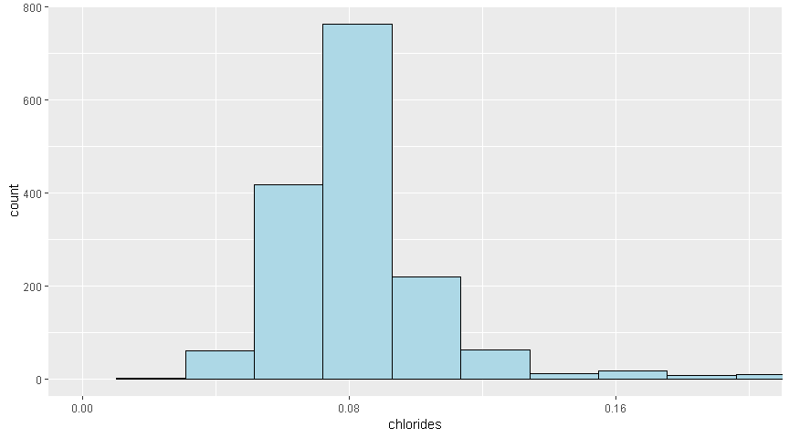

The amount of chlorides in the wines has a median value of 0.079 $g/dm^3$. A few outliers exists beyound the 0.28$g/dm^3$ The chlorides level are relatively little within the wine probably because a high value means higher salt levels.

## Free sulfur dioxide

```
##    Min. 1st Qu.  Median    Mean 3rd Qu.    Max.
##    1.00    7.00   14.00   15.87   21.00   72.00
```

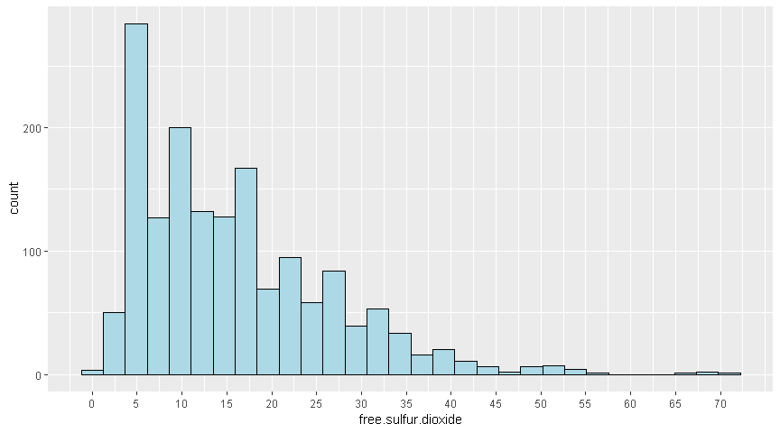

## Total sulfur dioxide

```
##    Min. 1st Qu.  Median    Mean 3rd Qu.    Max.
##    6.00   22.00   38.00   46.47   62.00  289.00
```

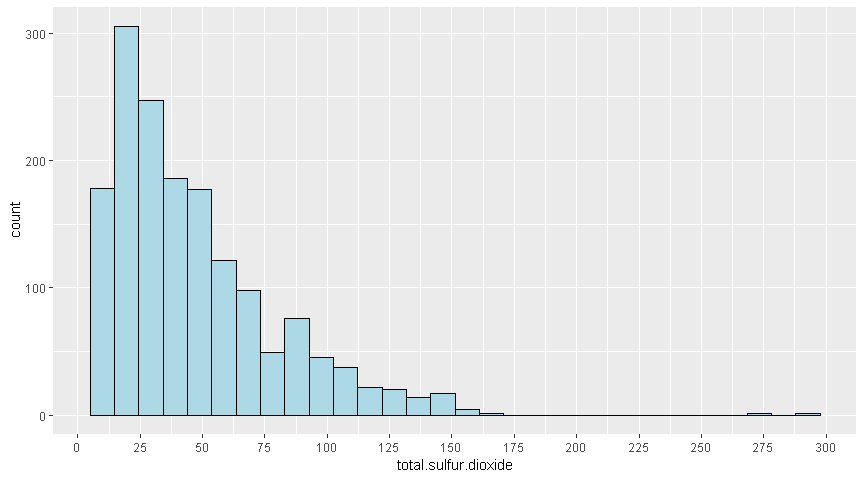

The concentration of total sulfur dioxide declines as we move towards the right hand side of the concentrate. A median value of 38 $mg/dm^3$ is noticed with two wines having a concentration of total sulphur dioxide greater than 200 $mg/dm^3$

## Density

```
##    Min. 1st Qu.  Median    Mean 3rd Qu.    Max.
##  0.9901  0.9956  0.9968  0.9967  0.9978  1.0037
```

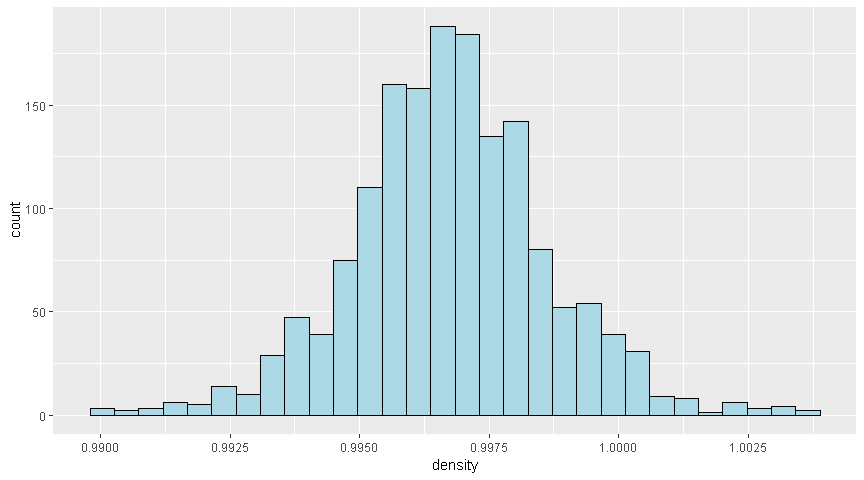

## pH

```
##    Min. 1st Qu.  Median    Mean 3rd Qu.    Max.
##   2.740   3.210   3.310   3.311   3.400   4.010
```

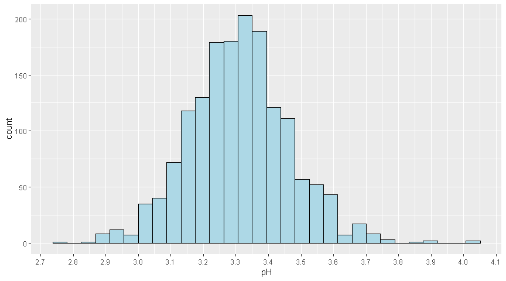

Wines tend to be more acidic than alkalinic hence justifying the low pH within the analysis. From Research, Low pH wines will taste tart and crisp, while higher pH wines are more susceptible to bacterial growth. Most wine pH levels fall around 3 or 4; about 3.0 to 3.4 is desirable for white wines, while about 3.3 to 3.6 is best for reds. As such the median value of 3.3 pH depicted within this analysis is absolutely normal. The text attached to this project also gives credence to this as it states that most wines have a pH of between 3-4.

## Sulphates

```
##    Min. 1st Qu.  Median    Mean 3rd Qu.    Max.
##  0.3300  0.5500  0.6200  0.6581  0.7300  2.0000
```

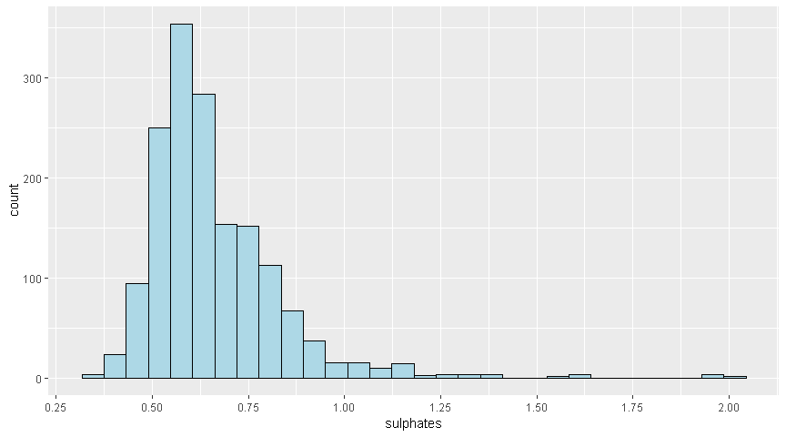

The sulphates used across the cross section of wines sampled shows a certain trend for higher sulphate values in wines with a major proportion having sulphate values with less than 1 $g/dm^3$. Although a few outliers exist with sulphate values above 1.2 $g/dm^3$ however the median value of sulphates is 0.62 $g/dm^3$ and most wines have a concentration between 0.55 $g/dm^3$ and 0.73 $g/dm^3$.Sulphate assists with antioxidation which leads to better storage.

## Alcohol

```
##    Min. 1st Qu.  Median    Mean 3rd Qu.    Max.
##    8.40    9.50   10.20   10.42   11.10   14.90
```

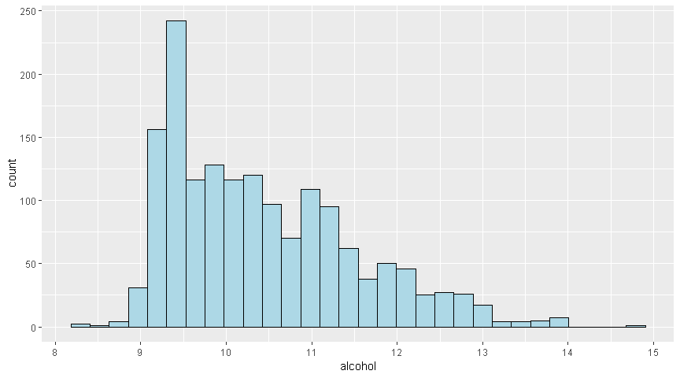

The alcohol concentration for wine often depends on the manufacturer of the wine. Redwine tends to have an alcohol content between 10- 14% which is synonymous with what obtains within the analysis where we see majority of the wines analyzed with an alcohol content between 8 & 14%.some outliers exist with an alcohol content of 14.90%

## Univariate Analysis Report

### What is the structure of your dataset?

The dataset comprises 12 variables, with 1599 red wines.Properties depicted within the dataset include fixed.acidity, volatile.acidity, citric.acid, residual.sugar, chlorides, free.sulfur.dioxide, total.sulfur.dioxide, density, pH, sulphates, alcohol, and quality.Most median values generated within the dataset are synonymous with real world properties of wine.

### What is/are the main feature(s) of interest in your dataset?

The pH & Quality of the wine are the main features of interest. Also, i’m a bit interested about the impact of removing constituents like sulphates and citric form the wine and how it will affect the quality since very little quantities of them are used.

### What other features in the dataset do you think will help support your?

I think it will be great to know how certain elements impact the quality of the wine as most red wines analyzed had an alcohol quantity of less than 15%. Would increasing certain elements affect the quality of the wine?

### Did you create any new variables from existing variables in the dataset?

No i did not

### Of the features you investigated, were there any unusual distributions?

The data seemed great and I did not notice any unusual distributions

# Bivariate Plots Section

## alcohol vs. Quality

```
## [1] "Median of alcohol by quality:"
## wines$quality: 3
## [1] 9.925
## --------------------------------------------------------
## wines$quality: 4
## [1] 10
## --------------------------------------------------------
## wines$quality: 5
## [1] 9.7
## --------------------------------------------------------
## wines$quality: 6
## [1] 10.5
## --------------------------------------------------------
## wines$quality: 7
## [1] 11.5
## --------------------------------------------------------
## wines$quality: 8
## [1] 12.15
```

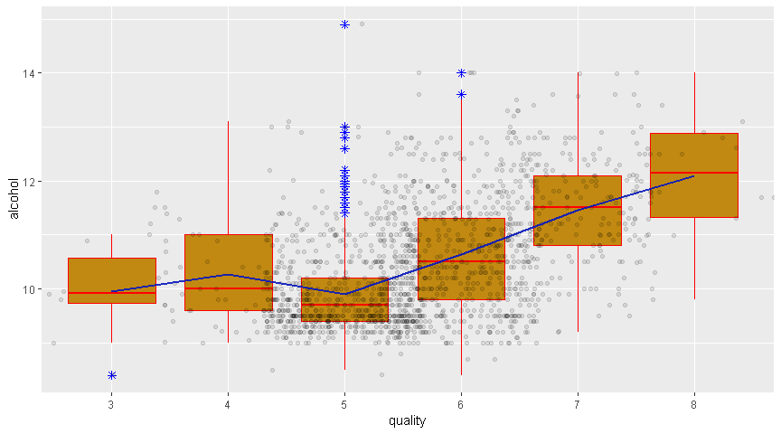

As the alcohol level increases, an increase in quality is also noticed. It is often percieved that the higher the alcohol level, the higher the quality of the wine.This is synpnmous with trends noticed in the chart.

## pH vs. Quality

```
## [1] "Median of pH by quality:"
## wines$quality: 3
## [1] 3.39
## --------------------------------------------------------
## wines$quality: 4
## [1] 3.37
## --------------------------------------------------------
## wines$quality: 5
## [1] 3.3
## --------------------------------------------------------
## wines$quality: 6
## [1] 3.32
## --------------------------------------------------------
## wines$quality: 7
## [1] 3.28
## --------------------------------------------------------
## wines$quality: 8
## [1] 3.23
```

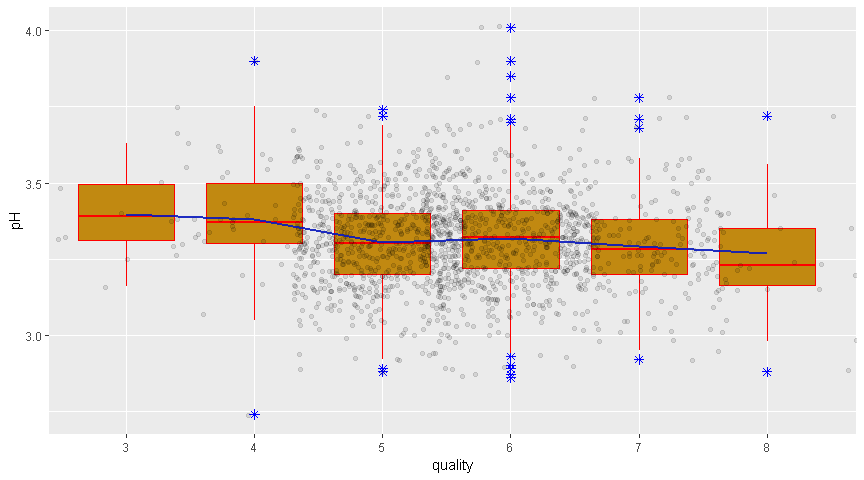

## Volatile Acidity vs. Quality

```
## [1] "Median of volatile.acidity by quality:"
## wines$quality: 3
## [1] 0.845
## --------------------------------------------------------
## wines$quality: 4
## [1] 0.67
## --------------------------------------------------------
## wines$quality: 5
## [1] 0.58
## --------------------------------------------------------
## wines$quality: 6
## [1] 0.49
## --------------------------------------------------------
## wines$quality: 7
## [1] 0.37
## --------------------------------------------------------
## wines$quality: 8
## [1] 0.37
```

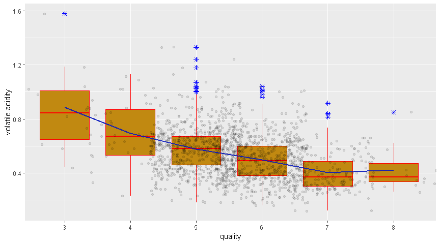

The trend depicts a higher wine quality as volatile acidity decreases. This is absolutely normal as a higher acetic acidity level leads to unpleasant vinegar taste in wines

## citric.acid vs. Quality

```
## [1] "Median of citric.acid by quality:"
## wines$quality: 3
## [1] 0.035
## --------------------------------------------------------
## wines$quality: 4
## [1] 0.09
## --------------------------------------------------------
## wines$quality: 5
## [1] 0.23
## --------------------------------------------------------
## wines$quality: 6
## [1] 0.26
## --------------------------------------------------------
## wines$quality: 7
## [1] 0.4
## --------------------------------------------------------
## wines$quality: 8
## [1] 0.42
```

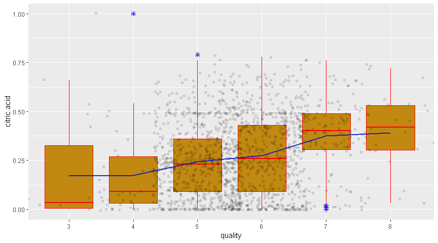

The trend depicts a higher wine quality as concentration of citric acidity increases.citic acid adds flavour and freshness to wines

## fixed acidity vs. Quality

```
## [1] "Median of fixed.acidity by quality:"
## wines$quality: 3
## [1] 7.5
## --------------------------------------------------------
## wines$quality: 4
## [1] 7.5
## --------------------------------------------------------
## wines$quality: 5
## [1] 7.8
## --------------------------------------------------------
## wines$quality: 6
## [1] 7.9
## --------------------------------------------------------
## wines$quality: 7
## [1] 8.8
## --------------------------------------------------------
## wines$quality: 8
## [1] 8.25
```

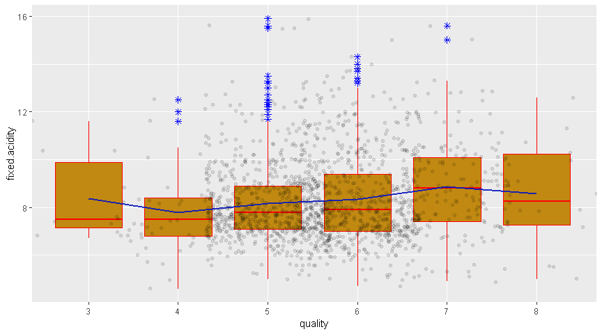

There seems to be a direct correlation between increased acidity levels and wine quality however the wines that have a quality of 8 seem to negate this trend. A big dispersion of acidity values is noticed across each quality scale. This may be a indicator that the quality cannot be predicted based only on the value of acidity and is the result of a combination of more variables.

## residual.sugar vs. Quality

```
## [1] "Median of residual.sugar by quality:"
## wines$quality: 3
## [1] 2.1
## --------------------------------------------------------
## wines$quality: 4
## [1] 2.1
## --------------------------------------------------------
## wines$quality: 5
## [1] 2.2
## --------------------------------------------------------
## wines$quality: 6
## [1] 2.2
## --------------------------------------------------------
## wines$quality: 7
## [1] 2.3
## --------------------------------------------------------
## wines$quality: 8
## [1] 2.1
```

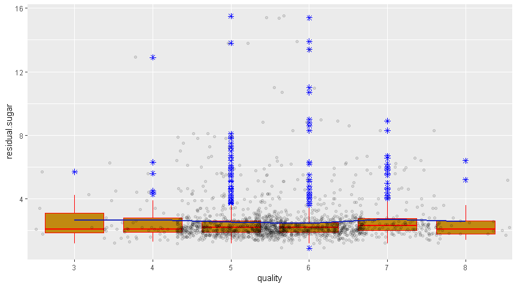

The amount of residual sugar used seems to have a low impact on the quality of the wine.

## chlorides vs. Quality

```
## [1] "Median of chlorides by quality:"
## wines$quality: 3
## [1] 0.0905
## --------------------------------------------------------
## wines$quality: 4
## [1] 0.08
## --------------------------------------------------------
## wines$quality: 5
## [1] 0.081
## --------------------------------------------------------
## wines$quality: 6
## [1] 0.078
## --------------------------------------------------------
## wines$quality: 7
## [1] 0.073
## --------------------------------------------------------
## wines$quality: 8
## [1] 0.0705
```

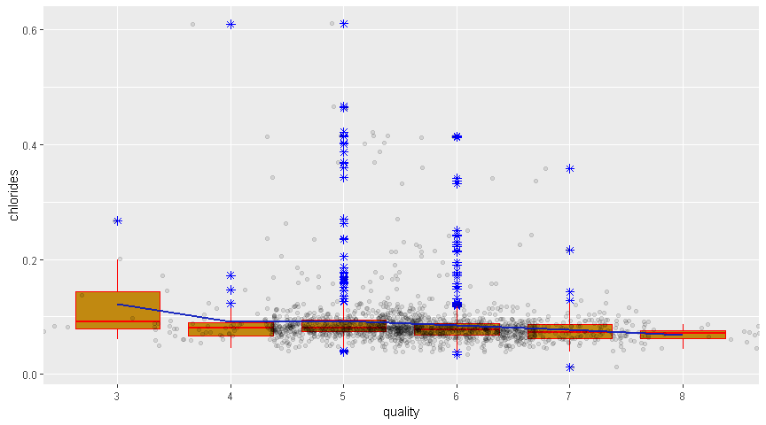

A higher quality is observed with reduced concentration of chlorides. This is normal as increased chloride levels means increased saltiness

## free.sulfur.dioxide vs. Quality

```
## [1] "Median of free.sulfur.dioxide by quality:"
## wines$quality: 3
## [1] 6
## --------------------------------------------------------
## wines$quality: 4
## [1] 11
## --------------------------------------------------------
## wines$quality: 5
## [1] 15
## --------------------------------------------------------
## wines$quality: 6
## [1] 14
## --------------------------------------------------------
## wines$quality: 7
## [1] 11
## --------------------------------------------------------
## wines$quality: 8
## [1] 7.5
```

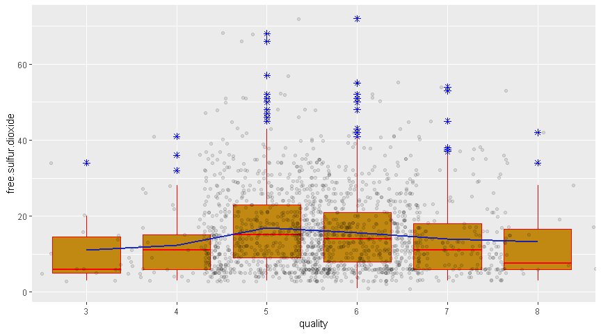

## total.sulfur.dioxide vs. Quality

```
## [1] "Median of total.sulfur.dioxide by quality:"
## wines$quality: 3
## [1] 15
## --------------------------------------------------------
## wines$quality: 4
## [1] 26
## --------------------------------------------------------
## wines$quality: 5
## [1] 47
## --------------------------------------------------------
## wines$quality: 6
## [1] 35
## --------------------------------------------------------
## wines$quality: 7
## [1] 27
## --------------------------------------------------------
## wines$quality: 8
## [1] 21.5
```

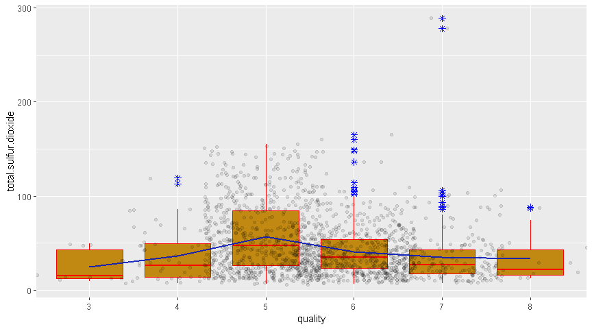

The same trend with free sulphur dioxide applies within the total sulphur dioxide scenario. The box plot trend tends to vary as the sulphur dioxide concentration goes beyond the 50 $g/dm^3$.

## density vs. Quality

```
## [1] "Median of density by quality:"
## wines$quality: 3
## [1] 0.997565
## --------------------------------------------------------
## wines$quality: 4
## [1] 0.9965
## --------------------------------------------------------
## wines$quality: 5
## [1] 0.997
## --------------------------------------------------------
## wines$quality: 6
## [1] 0.99656
## --------------------------------------------------------
## wines$quality: 7
## [1] 0.99577
## --------------------------------------------------------
## wines$quality: 8
## [1] 0.99494
```

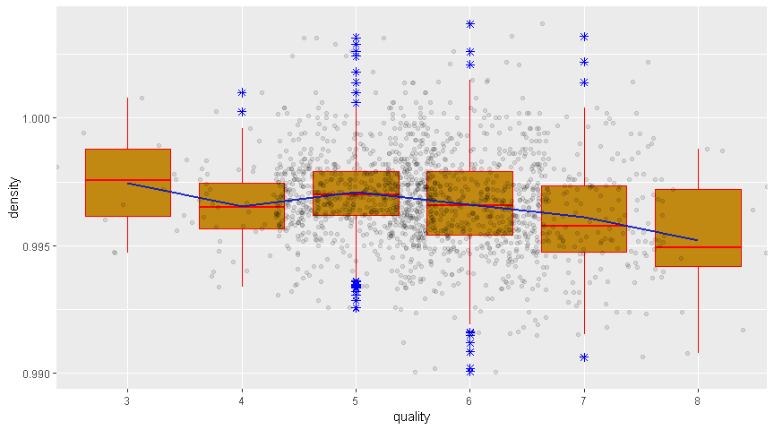

The lower the density of the wine, the higher the quality. This is as it should be as wine should be soft and smooth.Other factors may also determine this which include concentration of other elements used

## sulphates vs. Quality

```
## [1] "Median of sulphates by quality:"
## wines$quality: 3
## [1] 0.545
## --------------------------------------------------------
## wines$quality: 4
## [1] 0.56
## --------------------------------------------------------
## wines$quality: 5
## [1] 0.58
## --------------------------------------------------------
## wines$quality: 6
## [1] 0.64
## --------------------------------------------------------
## wines$quality: 7
## [1] 0.74
## --------------------------------------------------------
## wines$quality: 8
## [1] 0.74
```

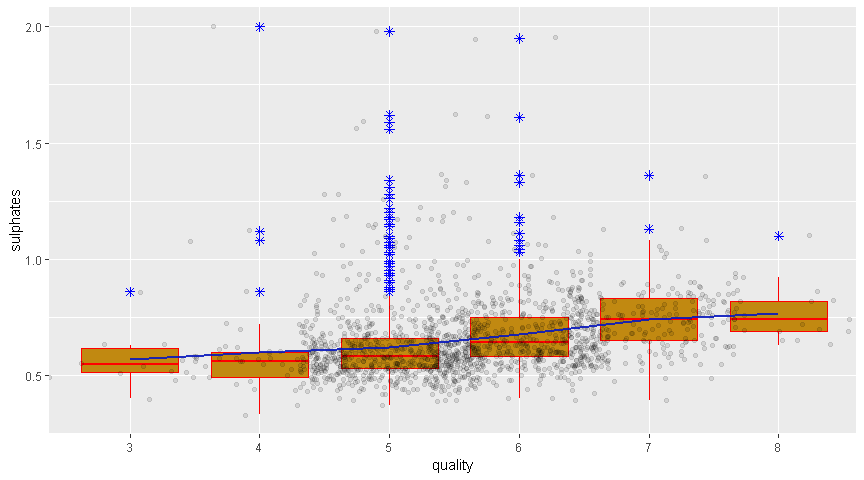

An increased quality is noticed with higher concentration of sulphates and ofcus as the text states, sulphates are neccessary for wine storage(antioxidation) which guarantees wine quality when proper volumes are used.

## citric.acid vs. Sulphates

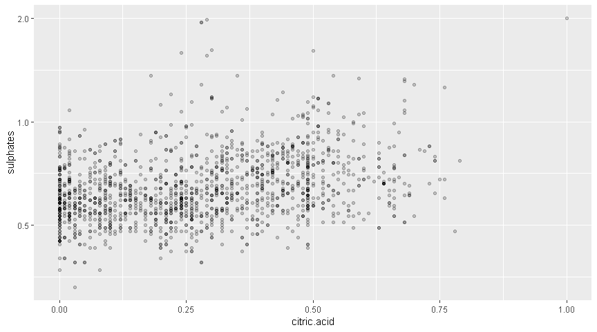

## alcohol vs. Density

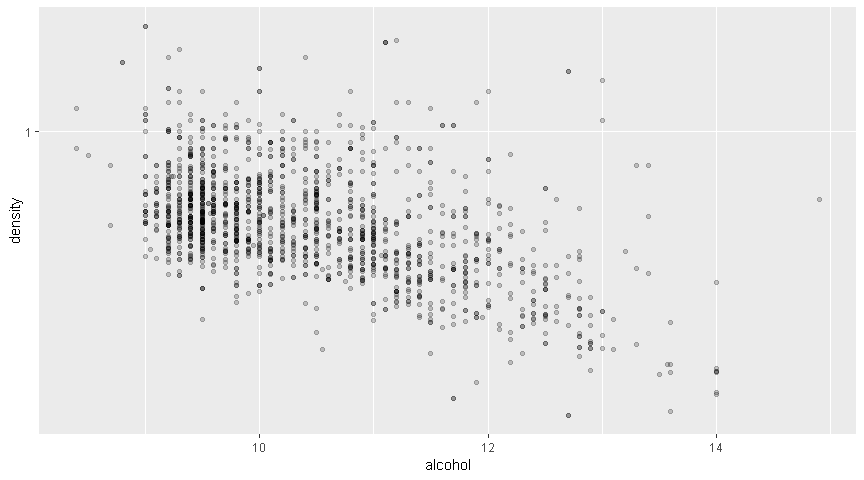

## fixed acidity vs. pH

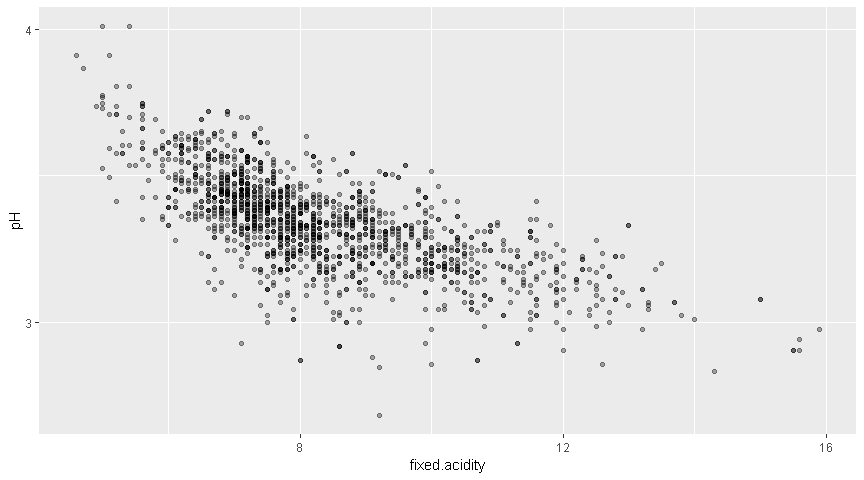

As it should be,the higher the acidity level, lower the pH level.

## alcohol vs. residual.sugar

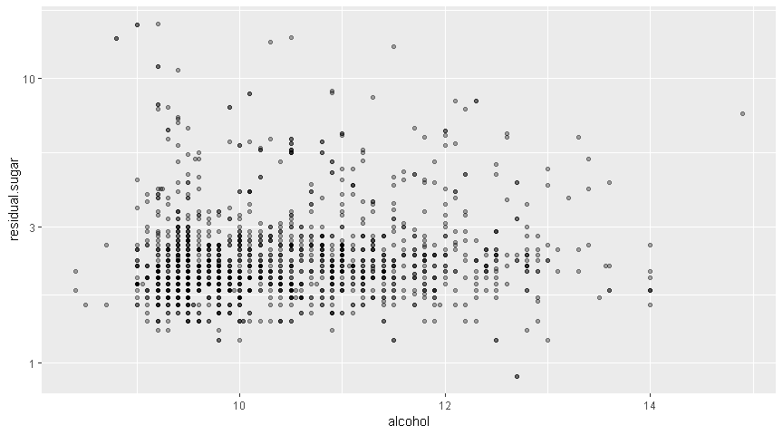

## Correlations with Quality

```
##                             [,1]
## fixed.acidity         0.11408367
## volatile.acidity     -0.38064651
## citric.acid           0.21348091
## residual.sugar        0.03204817
## chlorides            -0.18992234
## free.sulfur.dioxide  -0.05690065
## total.sulfur.dioxide -0.19673508
## density              -0.17707407
## pH                   -0.04367193
## sulphates             0.37706020
## alcohol               0.47853169
```

It is important to test which elements contribute the most to the quality of the wine and using spearman’s correlation coefficient we are able to see that an increase in certain elements help us achieve a higher wine quality.

## Bivariate analysis report

### What was the strongest relationship you found?

- The quality of red wine is determined hugely by its alcohol level

# Multivariate Plots Section

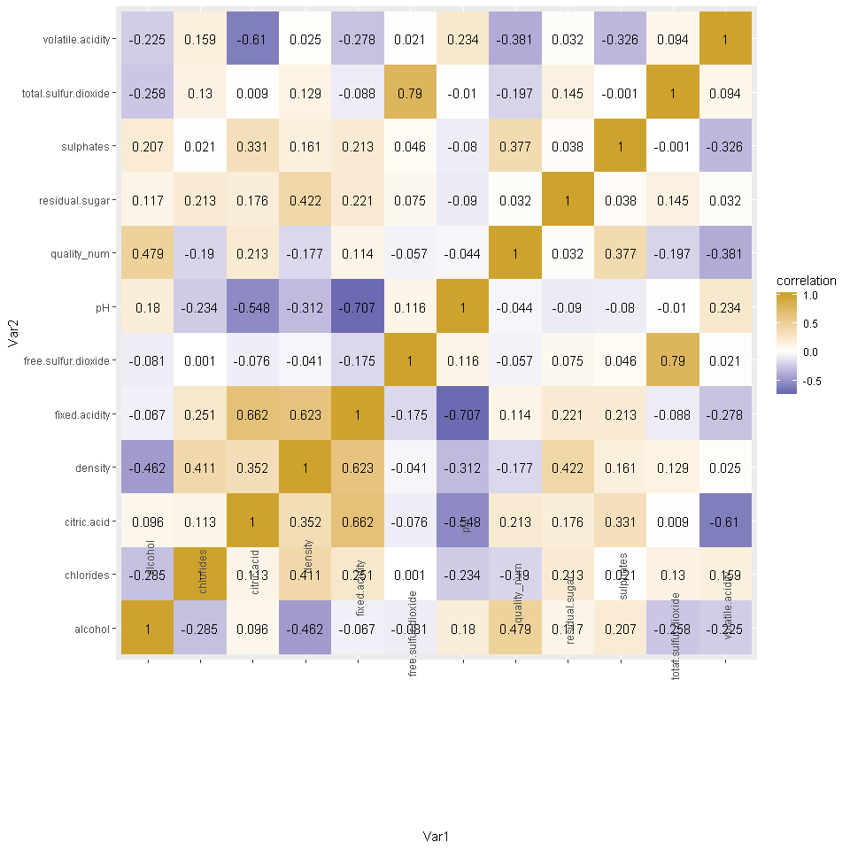

## Density, volatile acidity and quality

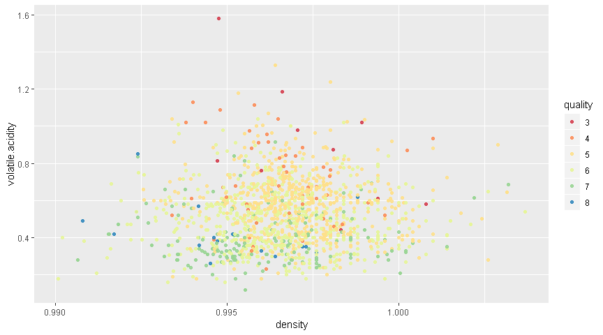